# BootLoader

Who Wants to Help Dennis Build a Bike?

Miles D. Williams

3/30/2020

First I open the packages I need to use for data manipulation and visualization.

```r
library(tidyverse)
library(ggpubr)
```

Now I get the data and give it a nice short name (`dt`)

```r
dt = read_csv('dataviz-01.csv')
dt # look at the data
```

```
## # A tibble: 50,000 x 14
##    userid eventType amountDonated timestamp           category gender age
##    <chr>  <chr>             <dbl> <dttm>              <chr>    <chr>  <chr>
##  1 69f62~ viewedPr~            NA 2019-10-01 00:00:04 sports   M      18-24
##  2 4459d~ viewedPr~            NA 2019-10-01 00:00:22 technol~ M      18-24
##  3 0db9e~ viewedPr~            NA 2019-10-01 00:00:32 environ~ M      55+
##  4 68195~ viewedPr~            NA 2019-10-01 00:00:38 technol~ M      18-24
##  5 9508a~ viewedPr~            NA 2019-10-01 00:00:51 sports   F      25-34
##  6 d420e~ viewedPr~            NA 2019-10-01 00:01:04 fashion  F      45-54
##  7 0e005~ viewedPr~            NA 2019-10-01 00:02:17 games    F      35-44
##  8 c6f18~ viewedPr~            NA 2019-10-01 00:02:18 technol~ F      35-44
##  9 2eb99~ viewedPr~            NA 2019-10-01 00:02:25 fashion  F      45-54
## 10 e040f~ viewedPr~            NA 2019-10-01 00:02:39 technol~ F      45-54
## # ... with 49,990 more rows, and 7 more variables: maritalStatus <chr>,
## #   device <chr>, city <chr>, state <chr>, latitude <dbl>, longitude <dbl>,
## #   zipCode <dbl>
```

First I want to do some basic exploratory analysis…

How many unique people are in the data?

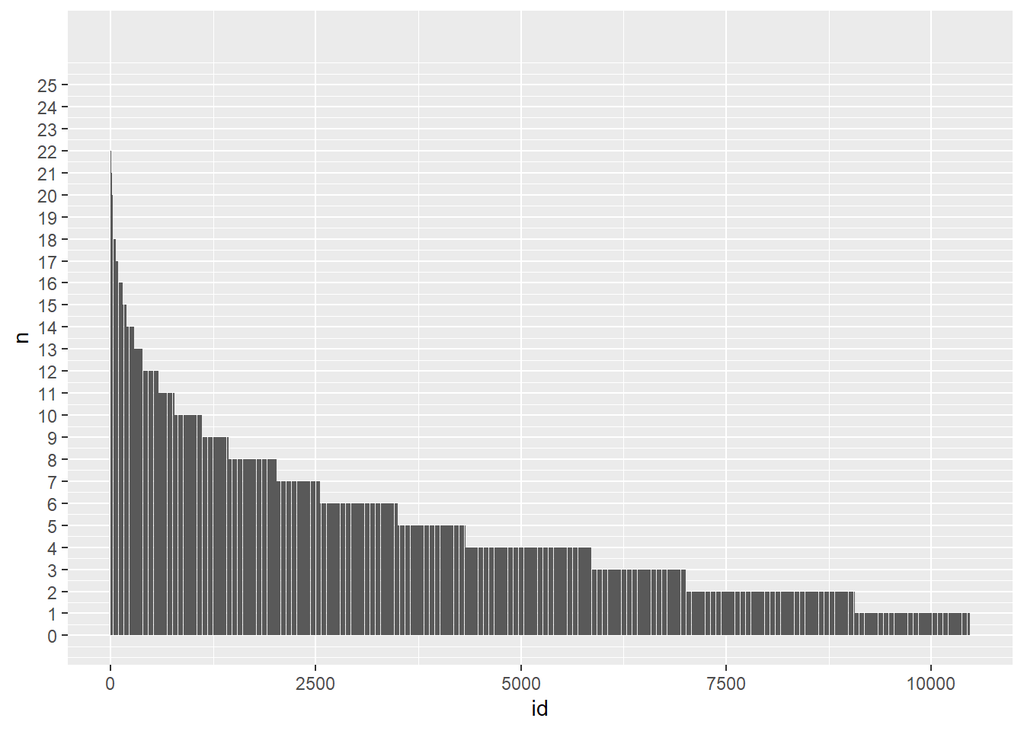

```r
dt %>%
  count(userid) %>%
  arrange(-n) %>%
  mutate(id=1:n()) %>%
  ggplot() +
  aes(id,n) +
  geom_col() +
  scale_y_continuous(breaks=0:25)
```

What categories of projects do people contribute funds toward?

```r
dt %>%
  count(category)
```

```
## # A tibble: 5 x 2
##   category        n
##   <chr>       <int>
## 1 environment  9980
## 2 fashion      9937
## 3 games        9955
## 4 sports      10099
## 5 technology  10029
```

It looks like we have 5 categories: environment, fashion, games, sports, and tech. And each of the categories seems to get plenty of love.

Now, it might also be useful to look at the people that either only viewed a project vs. those who funded.

```r
dt %>%
  count(category, eventType)
```

```
## # A tibble: 10 x 3
##    category    eventType         n
##    <chr>       <chr>         <int>
##  1 environment fundedProject  4089
##  2 environment viewedProject  5891
##  3 fashion     fundedProject  4073
##  4 fashion     viewedProject  5864
##  5 games       fundedProject  4173
##  6 games       viewedProject  5782
##  7 sports      fundedProject  4179
##  8 sports      viewedProject  5920
##  9 technology  fundedProject  4144
## 10 technology  viewedProject  5885
```

So just over half the people who view projects don’t fund them.

When they do donate, how much do they contribute? Below I look at the distribution of payments by category.

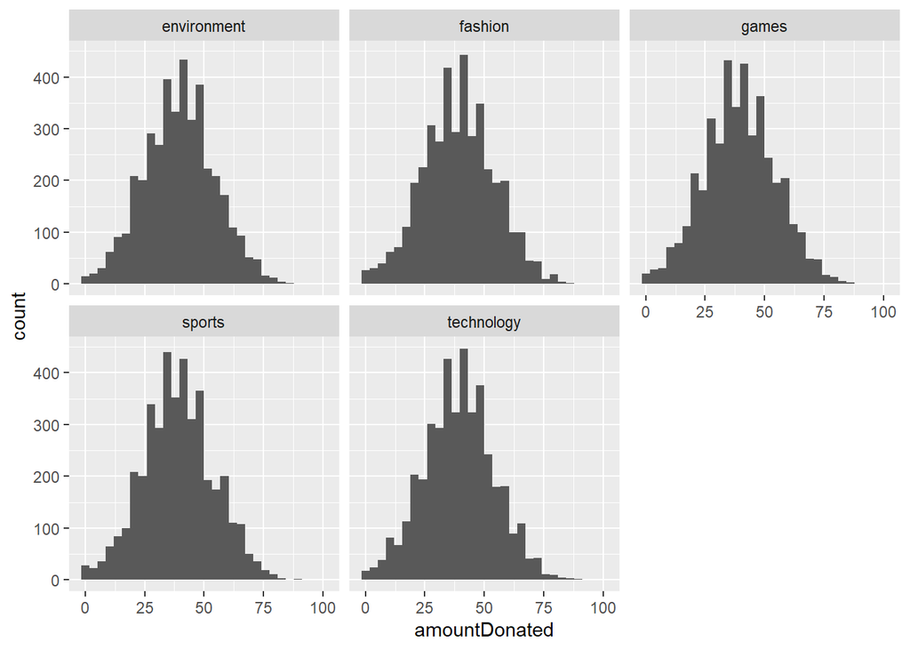

```r
dt %>%
  filter(eventType == 'fundedProject') %>%
  ggplot() +
  aes(amountDonated) +
  geom_histogram() +
  facet_wrap(~category)
```

Now for the Big Show. Let’s take a look at who is most likely to contribute to Dennis’ bike project. I do this by grouping the data by category, gender, age, marital status, type of device used (iOS or Android), and location (city, state).

I then compute some summary statistics of money donated to be computed by groups (mean, SD, min., max., N). I restrict the data to people who contribute funds. I then narrow the data down do people who contribute to environmental projects, sports projects, and and tech. projects. Why? Because I think these are the people who would be most interested in helping Dennis build his eco-friendly bike.

```r
dt %>%
  filter(
    amountDonated>0
  ) %>%
  group_by(
    category, gender, age, maritalStatus,
    device, city, state
  ) %>%
  summarize(
    total = sum(amountDonated),
    mean = mean(amountDonated),
    sd = sd(amountDonated),
    min = min(amountDonated),
    max = max(amountDonated),
    n = n()
  ) %>%
  arrange(-total) %>%
  filter(
    category %in% c('sports','environment','technology')
  ) -> top_funders
top_funders
```

```
## # A tibble: 6,618 x 13
## # Groups:   category, gender, age, maritalStatus, device, city [6,591]
##    category gender age   maritalStatus device city  state total  mean    sd
##    <chr>    <chr>  <chr> <chr>         <chr>  <chr> <chr> <dbl> <dbl> <dbl>
##  1 environ~ F      18-24 married       iOS    Atla~ GA     5214  40.4  14.9
##  2 sports   F      18-24 married       iOS    Atla~ GA     4958  39.0  14.8
##  3 technol~ M      18-24 married       iOS    Atla~ GA     4732  40.1  14.7
##  4 sports   M      18-24 married       iOS    Atla~ GA     4578  40.9  15.9
##  5 technol~ F      18-24 married       iOS    Atla~ GA     4076  37.1  14.4
##  6 environ~ M      18-24 married       iOS    Atla~ GA     3346  38.9  16.5
##  7 environ~ F      18-24 married       iOS    Lake~ OR     2605  40.7  16.5
##  8 sports   F      18-24 married       iOS    Lake~ OR     2523  44.3  13.3
##  9 environ~ F      18-24 single        andro~ Atla~ GA     2522  39.4  13.6
## 10 technol~ F      18-24 married       iOS    Lake~ OR     2363  39.4  14.1
## # ... with 6,608 more rows, and 3 more variables: min <dbl>, max <dbl>, n <int>
```

Now, that’s a pretty big table. The below figure synthesizes the results, reporting the most relevant information for who is most likely to contribute funds to Dennis’ project.

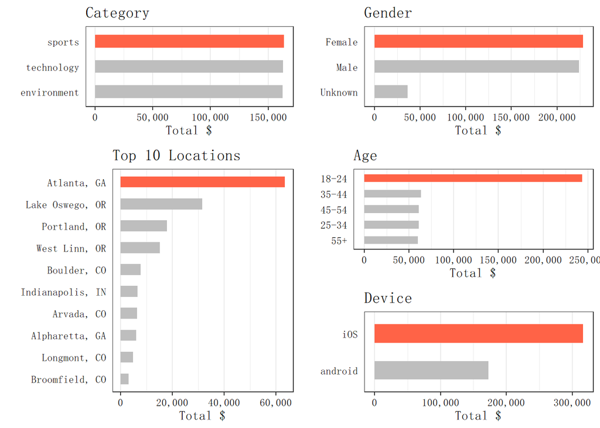

```r
extrafont::loadfonts(quiet=T,device='win') # for more fonts
top_funders %>%
  group_by(
    category
  ) %>%
  summarize(
    total = sum(total)
  ) %>%
  mutate(
    highlight = ifelse(total==max(total), "yes", "no" )
  ) %>%
  ggplot() +
  aes(reorder(category,total),total,
      fill = highlight) +
  geom_col(width = .5) +
  labs(x='',y='Total $',
       title = 'Category') +
  scale_y_continuous(
    labels=scales::comma_format()
  ) +
  scale_fill_manual(
    values=c("yes"="tomato", "no"="gray"),
    guide = F
  ) +
  theme_bw() +
  theme(
    panel.grid.major.y = element_blank(),
    panel.grid.minor.y = element_blank(),
    text = element_text(family = 'SimSun-ExtB'),
    axis.ticks.y = element_blank(),
    axis.text = element_text(color='black')
  ) +
  coord_flip() -> p1
top_funders %>%
  group_by(
    gender
  ) %>%
  summarize(
    total = sum(total)
  ) %>%
  mutate(
    highlight = ifelse(total==max(total), "yes", "no" )
  ) %>%
  mutate(
    gender = c('Female','Male','Unknown')
  ) %>%
  ggplot() +
  aes(reorder(gender,total),total,fill=highlight) +
  geom_col(width = .5) +
  labs(x='',y='Total $',
       title = 'Gender') +
  scale_y_continuous(
    labels=scales::comma_format()
  ) +
  scale_fill_manual(
    values=c("yes"="tomato", "no"="gray"),
    guide = F
  ) +
  theme_bw() +
  theme(
    panel.grid.major.y = element_blank(),
    panel.grid.minor.y = element_blank(),
    text = element_text(family = 'SimSun-ExtB'),
    axis.ticks.y = element_blank(),
    axis.text = element_text(color='black')
  ) +
  coord_flip() -> p2
top_funders %>%
  group_by(
    age
  ) %>%
  summarize(
    total = sum(total)
  ) %>%
   mutate(
    highlight = ifelse(total==max(total), "yes", "no" )
  ) %>%
  ggplot() +
  aes(reorder(age,total),total,fill=highlight) +
  geom_col(width = .5) +
  labs(x='',y='Total $',
       title = 'Age') +
  scale_y_continuous(
    labels=scales::comma_format()
  ) +
  scale_fill_manual(
    values=c("yes"="tomato", "no"="gray"),
    guide = F
  ) +
  theme_bw() +
  theme(
    panel.grid.major.y = element_blank(),
    panel.grid.minor.y = element_blank(),
    text = element_text(family = 'SimSun-ExtB'),
    axis.ticks.y = element_blank(),
    axis.text = element_text(color='black')
  ) +
  coord_flip() -> p3
top_funders %>%
  group_by(
    device
  ) %>%
  summarize(
    total = sum(total)
  ) %>%
   mutate(
    highlight = ifelse(total==max(total), "yes", "no" )
  ) %>%
  ggplot() +
  aes(reorder(device,total),total,fill=highlight) +
  geom_col(width = .5) +
  labs(x='',y='Total $',
       title = 'Device') +
  scale_y_continuous(
    labels=scales::comma_format()
  ) +
  scale_fill_manual(
    values=c("yes"="tomato", "no"="gray"),
    guide = F
  ) +
  theme_bw() +
  theme(
    panel.grid.major.y = element_blank(),
    panel.grid.minor.y = element_blank(),
    text = element_text(family = 'SimSun-ExtB'),
    axis.ticks.y = element_blank(),
    axis.text = element_text(color='black')
  ) +
  coord_flip() -> p4
top_funders %>%
  mutate(
    location = paste(city,state,sep=', ')
  ) %>%
  group_by(
    location
  ) %>%
  summarize(
    total = sum(total)
  ) %>%
  arrange(-total) %>%
  .[1:10,] %>%
  mutate(
    highlight = ifelse(total==max(total), "yes", "no" )
  ) %>%
  ggplot() +
  aes(reorder(location,total),total,fill=highlight) +
  geom_col(width = .5) +
  labs(x='',y='Total $',
       title = 'Top 10 Locations') +
  scale_y_continuous(
    labels=scales::comma_format()
  ) +
  scale_fill_manual(
    values=c("yes"="tomato", "no"="gray"),
    guide = F
  ) +
  theme_bw() +
  theme(
    panel.grid.major.y = element_blank(),
    panel.grid.minor.y = element_blank(),
    text = element_text(family = 'SimSun-ExtB'),
    axis.ticks.y = element_blank(),
    axis.text = element_text(color='black')
  ) +
  coord_flip() -> p5
gridExtra::grid.arrange(
  p1,p2,p3,p4,p5,
  layout_matrix = rbind(
    c(1,1,2,2),
    c(5,5,3,3),
    c(5,5,4,4)
  )
) -> full_plot
```

That doesn’t look too bad. However, I’d like to add a title, and save the output.

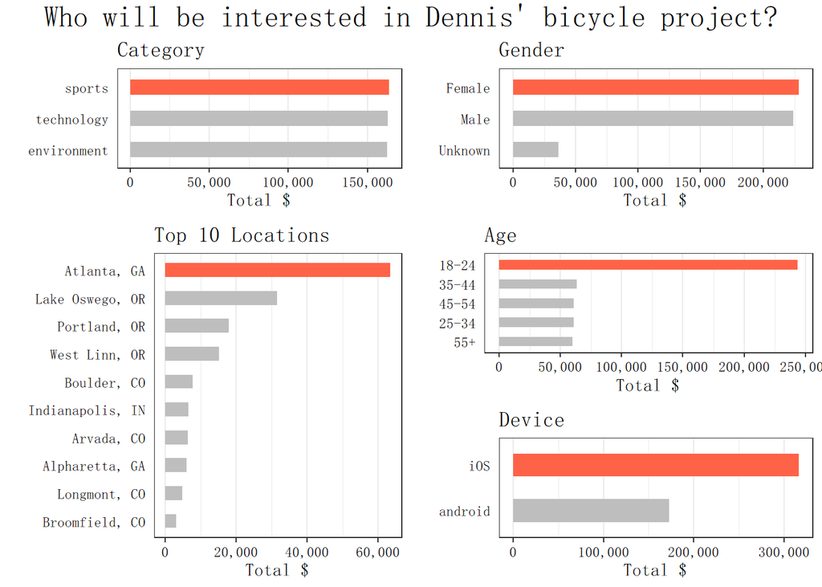

```r
annotate_figure(
  full_plot,
  top = text_grob(
    "Who will be interested in Dennis' bicycle project?",
    family = "SimSun-ExtB",
    size = 18
  )
) -> full_plot
ggsave(
  plot = full_plot,
  'plot1.png',
  units = 'in',
  height = 7,
  width = 10
)
full_plot
```

Done! So it looks like the best people to target are people women, age 18-24, who like donating to sports projects, who live in Atlanta, GA, and who use an iOS device.